# Week 3 laboratory

Prediction, unseen data and forecast metrics

Author

MTH1097 Financial and Actuarial Data Analysis

## Purpose

**How can we decide whether a model predicts an unseen financial or insurance outcome better than a simple baseline?**

This is a two-hour formative laboratory. Nothing is submitted for marks. You will calculate volatility, MAE, RMSE and $R^2$, then use them in two prediction settings:

1. next-month S&P 500 realised volatility;
2. claim frequency for a held-out motor policy.

The finance data use a chronological split. The insurance data use a frozen random policy split. In both cases, the test outcome plays no part in estimating its prediction.

## Working with AI

Use the same checked workflow as in Weeks 1 and 2:

1. state the prediction target, baseline and information date;
2. request one small piece of R code;
3. read and explain it before running it;
4. check units and at least one numerical identity;
5. write the interpretation yourself.

Ask AI to simplify code you cannot explain. Never accept a model because its training $R^2$ is large or because a function ran without an error.

## Timing and outputs

| Minutes | Task | Keep in your worksheet |
| --- | --- | --- |
| 0-20 | Define the metrics and volatility | Worked error table and volatility calculation |
| 20-65 | Fixed-split volatility prediction | Test metric table and dated forecast plot |
| 65-80 | Expanding-window evaluation | Revised metrics and largest-error table |
| 80-110 | Motor claim frequency | Policy metrics and risk-group plot |
| 110-120 | Compare the designs | Completed synthesis table and conclusion |

Complete the core tasks before attempting extensions.

## Setup

Extract the entire student package into a writable folder. Run this chunk first.

```r
library(dplyr)
library(tidyr)
library(readr)
library(ggplot2)
library(scales)

find_lab_dir <- function(start = ".") {
  start <- normalizePath(start, winslash = "/", mustWork = FALSE)
  current <- start
  while (TRUE) {
    candidates <- c(
      current,
      file.path(current, "week03_lab"),
      file.path(current, "week03", "lab"),
      file.path(current, ".."),
      file.path(current, "..", "week03_lab")
    )
    for (p in candidates) {
      if (dir.exists(p) && file.exists(file.path(p, "week03_lab_helpers.R"))) {
        return(normalizePath(p, winslash = "/"))
      }
    }
    parent <- dirname(current)
    if (parent == current) break
    current <- parent
  }
  return(NA_character_)
}

lab_dir <- find_lab_dir()
stopifnot(!is.na(lab_dir))
source(file.path(lab_dir, "week03_lab_helpers.R"))

data_candidates <- c(
  file.path(lab_dir, "data"),
  file.path(lab_dir, "..", "data"),
  file.path(lab_dir, "..", "data", "frozen")
)
data_dir <- data_candidates[
  file.exists(file.path(data_candidates, "sp500_vix_monthly.csv"))
][1]
stopifnot(!is.na(data_dir))

finance <- read_csv(file.path(data_dir, "sp500_vix_monthly.csv"),
                    show_col_types = FALSE) |>
  mutate(month = as.Date(month), target_month = as.Date(target_month))
motor <- read_csv(file.path(data_dir, "motor_frequency.csv.gz"),
                  show_col_types = FALSE) |>
  mutate(Area = factor(Area))

theme_set(theme_minimal(base_size = 12))
options(dplyr.summarise.inform = FALSE)
```

`DATA_DICTIONARY.md` gives the columns, units, sources and split conventions. The supplied data are frozen through 31 December 2025. No live download is required.

**Note**

The blank worksheet renders successfully. Add code and prose below each prompt, then render again to retain your results.

## Task 1: Metrics and volatility by hand and in R

### 1A. Errors, MAE and RMSE

Use these three outcomes and predictions:

| Observation | Actual | Predicted |
| --- | --- | --- |
| 1 | 10 | 12 |
| 2 | 20 | 18 |
| 3 | 30 | 24 |

1. Create vectors called `actual` and `predicted`.
2. Calculate signed errors $e_i=y_i-\widehat y_i$, absolute errors and squared errors.
3. Put all five columns in one data frame.
4. Calculate MAE and RMSE directly, then check them with `mae()` and `rmse()`.
5. State the units of both metrics if the target is measured in volatility points.

```r
# Create the vectors and complete the error table.
actual <- c(10, 20, 30)
predicted <- c(12, 18, 24)

errors <- tibble(
  observation = 1:3,
  actual = actual,
  predicted = predicted,
  error = actual - predicted,
  abs_error = abs(actual - predicted),
  squared_error = (actual - predicted)^2
)

mae_direct <- mean(errors$abs_error)
rmse_direct <- sqrt(mean(errors$squared_error))

mae_check <- mae(actual, predicted)
rmse_check <- rmse(actual, predicted)

errors
```

```
# A tibble: 3 × 6
  observation actual predicted error abs_error squared_error
        <int>  <dbl>     <dbl> <dbl>     <dbl>         <dbl>
1           1     10        12    -2         2             4
2           2     20        18     2         2             4
3           3     30        24     6         6            36
```

```r
mae_direct
```

```
[1] 3.333333
```

```r
rmse_direct
```

```
[1] 3.829708
```

```r
mae_check
```

```
[1] 3.333333
```

```r
rmse_check
```

```
[1] 3.829708
```

```r
# If the target is measured in volatility points, both MAE and RMSE are in volatility points.
```

**Checkpoint:** MAE is 3.33 and RMSE is 3.83, to two decimal places.

### 1B. R-squared relative to a mean prediction

Use the mean of `actual` as the baseline prediction for all three observations. Calculate

$$R^2=1-\frac{\sum_i(y_i-\widehat y_i)^2}
{\sum_i(y_i-\bar y)^2}.$$

Check your direct calculation with `r2_against()`.

```r
# Construct the mean baseline and calculate R-squared.
mean_actual <- mean(actual)
mean_baseline <- rep(mean_actual, length(actual))

baseline <- rep(mean(actual), length(actual))
model_squared_error <- sum((actual - predicted)^2)
mean_baseline_squared_error <- sum((actual - baseline)^2)
r2_direct <- 1 - model_squared_error / mean_baseline_squared_error
r2_check <- r2_against(actual, predicted, baseline)

model_squared_error
```

```
[1] 44
```

```r
mean_baseline_squared_error
```

```
[1] 200
```

```r
r2_direct
```

```
[1] 0.78
```

```r
r2_match <- (abs(r2_direct - r2_check) < 1e-12)
r2_match
```

```
[1] TRUE
```

**Checkpoint:** the model’s squared error is 44, the mean baseline’s squared error is 200, and $R^2=0.78$.

**Why do MAE and RMSE have target units while R-squared does not?**

MAE averages absolute target errors and RMSE takes the square root after averaging squared target errors. R-squared divides one sum of squared errors by another with the same units, so the units cancel.

### 1C. One volatility calculation

For daily decimal returns `c(-0.01, 0, 0.01)`:

1. calculate the sample standard deviation with `sd()`;
2. annualise it with $\sqrt{252}$;
3. express both results as percentages;
4. explain why neither result predicts whether the next return will be positive.

```r
# Calculate daily and annualised sample volatility.
returns <- c(-0.01, 0, 0.01)

daily_sd <- sd(returns)
annual_sd <- daily_sd * sqrt(252)

daily_vol_pct <- 100 * daily_sd
annual_vol_pct <- 100 * annual_sd

c(
  daily_sample_sd = daily_sd,
  annualised_sd = annual_sd,
  daily_vol_pct = daily_vol_pct,
  annual_vol_pct = annual_vol_pct
)
```

```
daily_sample_sd   annualised_sd   daily_vol_pct  annual_vol_pct
      0.0100000       0.1587451       1.0000000      15.8745079
```

```r
# Neither daily nor annualised volatility predicts the sign of the next return.
# Volatility is a dispersion measure, not a directional forecast.
```

**Checkpoint:** daily sample volatility is 1% and the annualised value is approximately 15.9%.

## Task 2: A fixed-split volatility forecast

One row of `finance` has information from the end of `month` and a target in `target_month`.

| Column | Meaning |
| --- | --- |
| `realised_vol` | Current month’s realised volatility, annualised percentage points |
| `vix_end` | Last VIX close in the current month |
| `next_realised_vol` | Realised volatility in the next calendar month |
| `sample_role` | Frozen chronological training or test role |

### 2A. Audit the prediction dates

1. Report the first and last `target_month` in each role and the number of rows.
2. Verify that `month < target_month` in every row.
3. Verify that training target months end in December 2009 and test target months begin in January 2010.
4. Check the data for missing target or predictor values.

```r
# Audit dates, roles and missing values.
finance_summary <- finance |>
  group_by(sample_role) |>
  summarise(
    first_target_month = min(target_month),
    last_target_month = max(target_month),
    n_rows = n(),
    .groups = "drop"
  )

month_order_check <- finance |>
  summarise(all_month_before_target = all(month < target_month, na.rm = TRUE))

train_end <- finance |>
  filter(sample_role == "train") |>
  summarise(max_target_month = max(target_month))

test_start <- finance |>
  filter(sample_role == "test") |>
  summarise(min_target_month = min(target_month))

training_boundary_check <- finance |>
  filter(sample_role == "train") |>
  summarise(
    training_ends_dec_2009 = max(target_month) == as.Date("2009-12-01")
  )

test_boundary_check <- finance |>
  filter(sample_role == "test") |>
  summarise(
    test_starts_jan_2010 = min(target_month) == as.Date("2010-01-01")
  )

missing_check <- finance |>
  summarise(
    missing_target_month = sum(is.na(target_month)),
    missing_month = sum(is.na(month)),
    missing_realised_vol = sum(is.na(realised_vol)),
    missing_vix_end = sum(is.na(vix_end)),
    missing_next_realised_vol = sum(is.na(next_realised_vol))
  )

finance_summary
```

```
# A tibble: 2 × 4
  sample_role first_target_month last_target_month n_rows
  <chr>       <date>             <date>             <int>
1 test        2010-01-01         2025-12-01           192
2 train       1990-02-01         2009-12-01           239
```

```r
month_order_check
```

```
# A tibble: 1 × 1
  all_month_before_target
  <lgl>
1 TRUE
```

```r
train_end
```

```
# A tibble: 1 × 1
  max_target_month
  <date>
1 2009-12-01
```

```r
test_start
```

```
# A tibble: 1 × 1
  min_target_month
  <date>
1 2010-01-01
```

```r
training_boundary_check
```

```
# A tibble: 1 × 1
  training_ends_dec_2009
  <lgl>
1 TRUE
```

```r
test_boundary_check
```

```
# A tibble: 1 × 1
  test_starts_jan_2010
  <lgl>
1 TRUE
```

```r
missing_check
```

```
# A tibble: 1 × 5
  missing_target_month missing_month missing_realised_vol missing_vix_end
                 <int>         <int>                <int>           <int>
1                    0             0                    0               0
# ℹ 1 more variable: missing_next_realised_vol <int>
```

```r
stopifnot(
  isTRUE(month_order_check$all_month_before_target),
  isTRUE(training_boundary_check$training_ends_dec_2009),
  isTRUE(test_boundary_check$test_starts_jan_2010),
  missing_check$missing_target_month == 0,
  missing_check$missing_month == 0,
  missing_check$missing_realised_vol == 0,
  missing_check$missing_vix_end == 0,
  missing_check$missing_next_realised_vol == 0
)
```

**Why would a random month split be misleading here?**

It could use later market regimes to estimate predictions assigned to earlier dates. The chronological split preserves the direction in which information arrives.

### 2B. Estimate the forecasts

Create `finance_train` and `finance_test` from `sample_role`.

1. **Historical-mean baseline:** predict every test target with the mean training target.
2. **Persistence baseline:** predict with the current row’s `realised_vol`.
3. **VIX model:** fit `next_realised_vol ~ vix_end` on training rows only and predict the test rows.
4. Report the fitted intercept, slope and training $R^2$.

```r
# Split, fit and add three prediction columns to finance_test.
finance_train <- finance |>
  filter(sample_role == "train")

finance_test <- finance |>
  filter(sample_role == "test")

historical_mean <- mean(finance_train$next_realised_vol)

finance_test <- finance_test |>
  mutate(
    historical_mean_pred = historical_mean,
    persistence_pred = realised_vol,
    vix_model = NA_real_
  )

vix_fit <- lm(next_realised_vol ~ vix_end, data = finance_train)

finance_test <- finance_test |>
  mutate(
    vix_model = as.numeric(predict(vix_fit, newdata = finance_test))
  )

coef(vix_fit)
```

```
(Intercept)     vix_end
 -3.4041270   0.9595946
```

```r
summary(vix_fit)$r.squared
```

```
[1] 0.6068199
```

```r
finance_test |>
  select(target_month, realised_vol, historical_mean_pred, persistence_pred, vix_model) |>
  head()
```

```
# A tibble: 6 × 5
  target_month realised_vol historical_mean_pred persistence_pred vix_model
  <date>              <dbl>                <dbl>            <dbl>     <dbl>
1 2010-01-01          10.5                  16.0            10.5       17.4
2 2010-02-01          16.5                  16.0            16.5       20.2
3 2010-03-01          18.1                  16.0            18.1       15.3
4 2010-04-01           7.47                 16.0             7.47      13.5
5 2010-05-01          15.1                  16.0            15.1       17.8
6 2010-06-01          32.1                  16.0            32.1       27.4
```

### 2C. Evaluate unseen months

Use `prediction_metrics()` or calculate each metric directly. The historical mean must be the baseline for test $R^2$.

```r
# Build a three-row table with test MAE, RMSE and R2_test.
metrics_table <- prediction_metrics(
  actual = finance_test$next_realised_vol,
  predictions = list(
    historical_mean = rep(mean(finance_train$next_realised_vol), nrow(finance_test)),
    persistence = finance_test$realised_vol,
    vix_model = finance_test$vix_model
  ),
  baseline_name = "historical_mean"
) |>
  mutate(
    MAE = MAE,
    RMSE = RMSE,
    R2_test = R2_test,
    .keep = "all"
  )

metrics_table
```

```
           method      MAE     RMSE     R2_test
1 historical_mean 6.398602 9.437774  0.00000000
2     persistence 5.801893 9.643555 -0.04408329
3       vix_model 4.428272 7.357874  0.39219322
```

**Checkpoint for the fixed model:** the VIX model has MAE about 4.43, RMSE about 7.36 and test $R^2$ about 39.2%. State MAE and RMSE in annualised volatility points.

### 2D. Plot the dated predictions

Make a time-series plot of actual test volatility and all three predictions. Use `target_month` on the horizontal axis. Keep the plot legible and label the target units.

[figure not shown]

```r
# Reshape the test predictions and make the plot.
plot_data <- finance_test |>
  select(target_month, realised_vol, historical_mean_pred, persistence_pred, vix_model) |>
  pivot_longer(
    cols = c(realised_vol, historical_mean_pred, persistence_pred, vix_model),
    names_to = "series",
    values_to = "volatility"
  ) |>
  mutate(
    series = recode(
      series,
      realised_vol = "Actual",
      historical_mean_pred = "Historical mean",
      persistence_pred = "Persistence",
      vix_model = "VIX model"
    )
  )

ggplot(plot_data, aes(x = target_month, y = volatility, colour = series)) +
  geom_line(linewidth = 0.8) +
  labs(
    x = "Target month",
    y = "Annualised volatility (% points)",
    colour = "Series",
    title = "Test-period realised volatility and forecasts"
  ) +
  theme_minimal(base_size = 12)
```

**Interpretation:** write four sentences covering:

- which model has the smallest MAE;
- - Answer: The VIX model has the smallest MAE, about 4.43 annualised volatility points, versus 5.80 for persistence and 6.40 for the historical mean.
- which has the smallest RMSE;
- - Answer: The VIX model also has the smallest RMSE, about 7.36 annualised volatility points, compared with 9.64 for persistence and 9.44 for the historical mean.
- what the VIX model’s test $R^2$ means;
- - Answer: Its test $R^2$ is about 0.392, meaning it explains about 39.2% of the variance in next-month realised volatility relative to the historical-mean baseline on the held-out test set.
- why this result does not yet imply a profitable trading strategy.
- - Answer: Forecast accuracy alone does not account for transaction costs, execution slippage, position sizing, or the economic value of the forecast in a trading rule; a more accurate volatility forecast is not automatically a profitable strategy.

## Task 3: Expanding-window forecasts

A fixed 2009 model ignores information that becomes available during 2010-2025. `expanding_volatility_forecasts()` repeats this dated procedure:

1. fit on target outcomes known by the forecast origin;
2. predict the next month;
3. record the error;
4. add the newly observed month to the next training window.

Read the function in `week03_lab_helpers.R` before running it. Explain how this line prevents leakage:

```r
training <- finance[finance$target_month < finance$target_month[j], ]
```

This line prevents leakage because it ensures each forecast is trained only on observations whose target_month is earlier than the current month being predicted, so no future information is used in the model fit.

```r
# Run the expanding helper and calculate its three-row metric table.
expanding_forecasts <- expanding_volatility_forecasts(finance)

expanding_metrics <- prediction_metrics(
  actual = expanding_forecasts$actual,
  predictions = list(
    historical_mean = expanding_forecasts$historical_mean,
    persistence = expanding_forecasts$persistence,
    vix_model = expanding_forecasts$vix_model
  ),
  baseline_name = "historical_mean"
) |>
  mutate(
    MAE = MAE,
    RMSE = RMSE,
    R2_test = R2_test,
    .keep = "all"
  )

expanding_metrics
```

```
           method      MAE     RMSE     R2_test
1 historical_mean 6.261663 9.411880  0.00000000
2     persistence 5.801893 9.643555 -0.04983606
3       vix_model 4.441275 7.395698  0.38254466
```

**Checkpoint:** the expanding VIX model has MAE about 4.44, RMSE about 7.40 and test $R^2$ about 38.3%.

Identify the five VIX-model predictions with the largest absolute errors. Compare their effect on MAE and RMSE.

```r
# Create and display the five-row largest-error table.
top5_idx <- order(
  abs(expanding_forecasts$actual - expanding_forecasts$vix_model),
  decreasing = TRUE
)[1:5]

largest_error_table <- expanding_forecasts[top5_idx, c("target_month", "actual", "vix_model")]

largest_error_table$error <- largest_error_table$actual - largest_error_table$vix_model
largest_error_table$abs_error <- abs(largest_error_table$error)

largest_error_table <- largest_error_table[
  order(-largest_error_table$abs_error),
  c("target_month", "actual", "vix_model", "error", "abs_error")
]

largest_error_table
```

```
    target_month   actual vix_model    error abs_error
123   2020-03-01 94.18699 34.269722 59.91727  59.91727
184   2025-04-01 48.82943 17.964929 30.86450  30.86450
20    2011-08-01 47.18376 20.605793 26.57797  26.57797
68    2015-08-01 26.76583  8.297078 18.46876  18.46876
98    2018-02-01 27.48930  9.723608 17.76569  17.76569
```

```r
# Compare the effect of these five large misses on MAE and RMSE.
mae_all <- mae(expanding_forecasts$actual, expanding_forecasts$vix_model)
rmse_all <- rmse(expanding_forecasts$actual, expanding_forecasts$vix_model)

mae_without_top5 <- mae(
  expanding_forecasts$actual[-top5_idx],
  expanding_forecasts$vix_model[-top5_idx]
)
rmse_without_top5 <- rmse(
  expanding_forecasts$actual[-top5_idx],
  expanding_forecasts$vix_model[-top5_idx]
)

comparison <- data.frame(
  metric = c("MAE", "RMSE"),
  all_rows = c(mae_all, rmse_all),
  without_top5 = c(mae_without_top5, rmse_without_top5)
)

comparison
```

```
  metric all_rows without_top5
1    MAE 4.441275     3.738666
2   RMSE 7.395698     4.957520
```

**TipInterpretation check**

Persistence has lower MAE than the historical mean but higher RMSE and negative test $R^2$. Explain this using the extra influence of large squared errors.

## Task 4: Motor claim frequency

The file contains 677,991 public, anonymised policy observations. The build retains all supplied rows because selected fields are complete, exposure is positive and claim counts are non-negative. Counts and exposures were not capped.

### 4A. Audit the policy split and target

1. Count training and test policies.
2. Confirm that `IDpol` is unique and that no identifier occurs in both roles.
3. Summarise `ClaimNb`, `Exposure` and `claim_frequency`.
4. Calculate the share of policies with zero claims.
5. Explain why `ClaimNb / Exposure` can be large for a short policy with one claim.

```r
# Audit the policy data without dropping or changing rows.

# 1. Count training and test policies.
motor |>
  group_by(sample_role) |>
  summarise(policy_count = n(), .groups = "drop")
```

```
# A tibble: 2 × 2
  sample_role policy_count
  <chr>              <int>
1 test              204219
2 train             473772
```

```r
# 2. Confirm that IDpol is unique and that no identifier occurs in both roles.
motor |>
  group_by(IDpol) |>
  summarise(
    n_rows = n(),
    n_roles = n_distinct(sample_role),
    .groups = "drop"
  ) |>
  summarise(
    duplicate_ids = sum(n_rows > 1L),
    ids_in_both_roles = sum(n_roles > 1L),
    total_unique_ids = n()
  )
```

```
# A tibble: 1 × 3
  duplicate_ids ids_in_both_roles total_unique_ids
          <int>             <int>            <int>
1             0                 0           677991
```

```r
# 3. Summarise ClaimNb, Exposure and claim_frequency.
motor |>
  mutate(claim_frequency = ClaimNb / Exposure) |>
  select(ClaimNb, Exposure, claim_frequency) |>
  summarise(
    across(
      everything(),
      list(
        min = min,
        mean = mean,
        median = median,
        max = max,
        sd = sd
      ),
      .names = "{.col}_{.fn}"
    )
  ) |>
  t()
```

```
                               [,1]
ClaimNb_min              0.00000000
ClaimNb_mean             0.03900347
ClaimNb_median           0.00000000
ClaimNb_max             16.00000000
ClaimNb_sd               0.20716880
Exposure_min             0.00273224
Exposure_mean            0.52874276
Exposure_median          0.49000000
Exposure_max             2.01000000
Exposure_sd              0.36444064
claim_frequency_min      0.00000000
claim_frequency_mean     0.11862902
claim_frequency_median   0.00000000
claim_frequency_max    365.00000000
claim_frequency_sd       2.02458143
```

```r
# 4. Calculate the share of policies with zero claims.
motor |>
  summarise(
    total_policies = n(),
    zero_claim_policies = sum(ClaimNb == 0L),
    zero_claim_share = mean(ClaimNb == 0L)
  )
```

```
# A tibble: 1 × 3
  total_policies zero_claim_policies zero_claim_share
           <int>               <int>            <dbl>
1         677991              653047            0.963
```

```r
# 5. Explain why ClaimNb / Exposure can be large for a short policy with one claim.
# A policy with Exposure = 0.1 (10% of a year) and ClaimNb = 1 has
# claim_frequency = 1 / 0.1 = 10, which annualises the single claim.
# The frequency metric expresses claims per year of exposure, not per policy.
motor |>
  filter(ClaimNb == 1L) |>
  mutate(claim_frequency = ClaimNb / Exposure) |>
  slice_min(Exposure, n = 5) |>
  select(IDpol, ClaimNb, Exposure, claim_frequency)
```

```
# A tibble: 8 × 4
    IDpol ClaimNb Exposure claim_frequency
    <dbl>   <dbl>    <dbl>           <dbl>
1 2124033       1  0.00274             365
2 2185848       1  0.00274             365
3 3088885       1  0.00274             365
4   75290       1  0.00546             183
5   81178       1  0.00546             183
6   91820       1  0.00546             183
7 4169479       1  0.00546             183
8 4169952       1  0.00546             183
```

### 4B. Portfolio baseline and weighted linear model

Create `motor_train` and `motor_test`. Use training policies only to calculate

$$\widehat\lambda_0=
\frac{\sum_{i\in train}N_i}{\sum_{i\in train}E_i}.$$

Then fit

```r
lm(claim_frequency ~ BonusMalus + DrivAge + I(DrivAge^2) + Area,
   data = motor_train, weights = Exposure)
```

Do not add predictors after looking at test performance.

```r
# Calculate the training portfolio rate and fit the weighted model.

# Create motor_train and motor_test.
motor_train <- motor |>
  filter(sample_role == "train") |>
  mutate(claim_frequency = ClaimNb / Exposure)

motor_test <- motor |>
  filter(sample_role == "test") |>
  mutate(claim_frequency = ClaimNb / Exposure)

# Calculate the training portfolio rate (lambda_0).
portfolio_rate <- with(
  motor_train,
  sum(ClaimNb) / sum(Exposure)
)

# Fit the weighted least-squares model on training data.
frequency_fit <- lm(
  claim_frequency ~ BonusMalus + DrivAge + I(DrivAge^2) + Area,
  data = motor_train,
  weights = Exposure
)
```

### 4C. Expected counts and policy-level metrics

For each test policy, calculate

$$\widehat N_{0i}=E_i\widehat\lambda_0,
\qquad
\widehat N_i=E_i\widehat F_i.$$

Compare observed `ClaimNb` with both expected counts using MAE, RMSE and test $R^2$.

```r
# Predict test frequency, convert to expected counts and calculate metrics.

# Predict test frequency.
motor_test$predicted_frequency <- predict(frequency_fit, newdata = motor_test)

# Calculate expected counts using baseline portfolio rate and model predictions.
motor_test$baseline_count <- motor_test$Exposure * portfolio_rate
motor_test$predicted_count <- motor_test$Exposure * motor_test$predicted_frequency

# Compare observed ClaimNb with both expected counts using MAE, RMSE and test R².
prediction_metrics(
  actual = motor_test$ClaimNb,
  predictions = list(
    baseline = motor_test$baseline_count,
    model = motor_test$predicted_count
  ),
  baseline_name = "baseline"
)
```

```
    method        MAE      RMSE    R2_test
1 baseline 0.07410145 0.2063158 0.00000000
2    model 0.07310661 0.2045531 0.01701403
```

**Checkpoint:** the model’s policy-level MAE is about 0.0731 claims, RMSE about 0.2046 claims and test $R^2$ about 1.7%.

Count negative predicted frequencies. Do not replace them with zero before reporting the count.

**Why can a small policy-level R-squared coexist with useful risk ranking?**

Most individual outcomes are zero and a claim remains highly uncertain. Aggregating many similarly predicted policies reduces individual noise and reveals differences in their average rates.

### 4D. Risk groups on held-out policies

Use `risk_group_summary()` to divide test policies into ten groups by predicted frequency. Plot observed group frequency and mean predicted frequency against group number.

```r
# Build the ten-group table and calibration plot.

# Divide test policies into ten groups by predicted frequency.
groups <- risk_group_summary(
  motor_test,
  predicted_frequency = motor_test$predicted_frequency,
  groups = 10
)

# Print the ten-group table.
as_tibble(groups)
```

```
# A tibble: 10 × 6
   risk_group policies exposure claims mean_predicted_frequ…¹ observed_frequency
        <int>    <int>    <dbl>  <dbl>                  <dbl>              <dbl>
 1          1    20422   12754.    474                 0.0356             0.0372
 2          2    20422   12556.    559                 0.0461             0.0445
 3          3    20422   11857.    563                 0.0516             0.0475
 4          4    20422   11864.    592                 0.0565             0.0499
 5          5    20422   11327.    639                 0.0610             0.0564
 6          6    20422   10985.    746                 0.0674             0.0679
 7          7    20422   10325.    780                 0.0745             0.0755
 8          8    20422    9509.   1010                 0.0931             0.106
 9          9    20422    8689.   1036                 0.126              0.119
10         10    20421    8153.   1510                 0.183              0.185
# ℹ abbreviated name: ¹mean_predicted_frequency
```

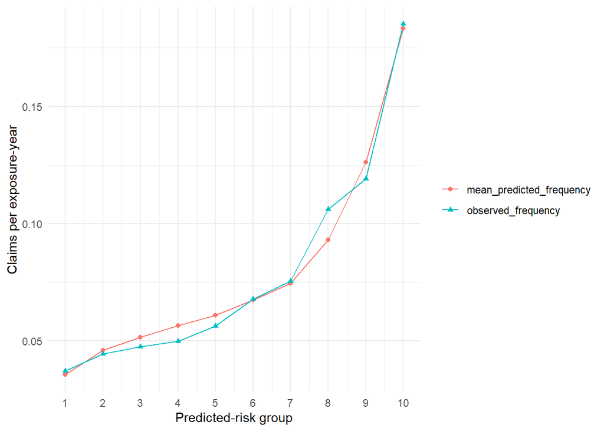

```r
# Plot observed group frequency and mean predicted frequency against group number.
groups |>
  select(risk_group, mean_predicted_frequency, observed_frequency) |>
  pivot_longer(-risk_group, names_to = "series", values_to = "frequency") |>
  ggplot(aes(risk_group, frequency, colour = series, shape = series)) +
  geom_line() +
  geom_point() +
  scale_x_continuous(breaks = 1:10) +
  labs(x = "Predicted-risk group", y = "Claims per exposure-year",
       colour = NULL, shape = NULL) +
  theme_minimal()
```

**Checkpoint:** observed frequency is about 0.037 in the lowest group and 0.185 in the highest, a ratio close to 5.

Write three sentences distinguishing prediction from causation, risk ranking from individual certainty, and empirical usefulness from permission to use a rating factor.

### Optional extension: a non-negative mean

Fit a Poisson count model with exposure as an offset:

```r
glm(ClaimNb ~ BonusMalus + DrivAge + I(DrivAge^2) + Area +
      offset(log(Exposure)),
    data = motor_train, family = poisson())
```

Check whether its expected counts are negative. Do not compare likelihoods or derive the model this week.

## Task 5: Compare the two prediction designs

Complete the table.

| Question | Finance | Insurance |
| --- | --- | --- |
| What is one row? | One monthly observation of realized and forecast volatility | One insurance policy |
| What is the target? | Next month’s realized volatility | Number of claims in the policy period |
| When are predictors known? | At the end of the origin month, before the target month occurs | When the policy is underwritten, before claims are observed |
| What is the baseline? | Historical mean of training volatility | Portfolio claim rate (total training claims / total training exposure) |
| Why is the split appropriate? | Chronological: training months precede test months; expanding window ensures no future data enters training | Random: training and test are independent samples; both represent the same population of policies |
| What are the MAE and RMSE units? | Percentage volatility (annualized, e.g., 15%) | Claim counts (number of claims) |
| What does test $R^2$ compare? | Relative error reduction of the model versus historical-mean baseline on test forecasts | Relative error reduction of the model versus portfolio-rate baseline on test claim counts |
| What claim is supported? | The VIX model reduces test forecast error relative to the historical-mean baseline | The frequency model reduces test claim-count error relative to the portfolio-rate baseline |
| What stronger claim is unsupported? | The VIX model will reduce forecast error on future months beyond the test period | The frequency model will reduce claim-count error on future policies beyond the test set |

Finish with six to eight evidence-based sentences. Include at least one numerical test result from each application and one limitation of each conclusion.

## Exit check

Without looking back, answer:

1. What does MAE average?
2. Why does RMSE react more strongly to one large error?
3. What is the denominator of ordinary training $R^2$?
4. Why can test $R^2$ be negative?
5. Why do the two applications use different train/test splits?